# Trabajo 2 · Equipo STMSYJ

Tres series: escala, orden de integración, identificación, estimación y validación de modelos ARIMA

Autor/a

Sofía Cadavid Rueda, Mariana Castaño Celis y Sarah Catalina Criollo García

Fecha de publicación

29 de noviembre de 2026

# 1 Estructura, README, herramientas y Git

La estructura del repositorio, los paquetes, los comandos para correrlo, la tabla de herramientas y la declaración de uso de IA están en `README.md`. El código de cada sección está en `R/` (un archivo por etapa, sin objetos globales) y `analisis/correr-todo.R` lo corre de principio a fin desde la raíz. La salida de `sessionInfo()` queda en `sesion-info.txt`.

# 2 Las tres series y su contexto

## 2.1 Ficha de cada serie

Ficha de las tres series, calculada con código.

| Serie | Nombre | Unidad | Frecuencia | Inicio | Fin | T | Mínimo | Máximo | Media |
| --- | --- | --- | --- | --- | --- | --- | --- | --- | --- |
| 1 | Material estéril acumulado en la escombrera norte | millones de toneladas | trimestral | 2002-07-01 | 2026-04-01 | 96 | 5,42 | 103,17 | 60,56 |
| 2 | Precio de cierre semanal de la acción de la empresa | pesos por acción | semanal | 2022-09-05 | 2026-06-29 | 200 | 1.566,00 | 7.414,00 | 3.528,41 |
| 3 | Costo directo de extracción por tonelada de mineral | dólares por tonelada | mensual | 2014-07-01 | 2026-06-01 | 144 | 31,02 | 53,54 | 42,38 |

## 2.2 Qué mide cada serie y qué rasgo pesa en la decisión

**Serie 1.** Mide el inventario de estéril depositado en la escombrera norte, en millones de toneladas acumuladas al cierre del trimestre; su primera diferencia es el estéril depositado en el trimestre. Para decidir cuándo radicar la ampliación pesa el **crecimiento por período**: con 103,17 Mt al cierre de 2026-04 frente a un tope de 125 Mt, lo que importa es a qué ritmo se depositan los 21,83 Mt restantes y si ese ritmo cambia, porque el trámite tarda cuatro trimestres.

**Serie 2.** Mide el precio de cierre semanal de la acción, en pesos por acción. Para el calendario de venta del paquete pesan la **persistencia de los choques** y su tamaño: si los rendimientos semanales no son predecibles, el mejor pronóstico es el último precio y lo que decide entre vender de una vez o por tramos es cuánto se abre la incertidumbre en ocho semanas.

**Serie 3.** Mide el costo directo medio de extraer una tonelada de mineral, en dólares por tonelada. Para fijar la ley de corte pesa el **nivel** de los próximos seis meses, y con él la persistencia de los choques: cada dólar por tonelada de error cuesta cerca de 1,1 millones de dólares al mes, en cualquiera de las dos direcciones.

# 3 Escala y estabilización de la varianza

## 3.1 Gráfico en el tiempo y dispersión contra nivel

Para cada serie se presenta el gráfico en el tiempo y el gráfico, en escala logarítmica en los dos ejes, de la desviación estándar de la primera diferencia contra el nivel medio en bloques consecutivos de igual tamaño (`sd_nivel()`). Si la desviación es proporcional a una potencia del nivel, $\sigma_t \propto \mu_t^{\,b}$, la transformación $g(Z)=Z^{1-b}$ la estabiliza, de modo que la pendiente $b$ de la recta en escala log-log se lee como $\lambda = 1 - b$: $b \approx 0$ indica $\lambda = 1$ (no transformar) y $b \approx 1$, $\lambda = 0$ (logaritmo).

**Por qué la desviación de la diferencia y no la de la serie.** Las tres series no son estacionarias en media. Dentro de un bloque, la desviación estándar de $Z_t$ mide sobre todo cuánto se desplazó el nivel durante el bloque (la tendencia o la deriva local), no el tamaño de los choques; crece con la longitud del bloque y con la pendiente local aunque la varianza de los choques sea constante. La primera diferencia quita el nivel local y deja la variación de período a período, que es la dispersión que la transformación debe estabilizar. En la serie 1 esto es evidente: la desviación de $Z_t$ en un bloque de 8 trimestres está dominada por el crecimiento acumulado de cerca de 8 Mt en el bloque, mientras que la de $\nabla Z_t$ es de unas centésimas de Mt.

El tamaño de bloque se fijó en 8 trimestres (2 años, 12 bloques) para la serie 1, 10 semanas (20 bloques) para la serie 2 y 12 meses (1 año, 12 bloques) para la serie 3: lo bastante largo para estimar una desviación con al menos 7 diferencias y lo bastante corto para tener 12 bloques o más. Como la pendiente depende del bloque, se reporta su sensibilidad.

### 3.1.1 Serie 1

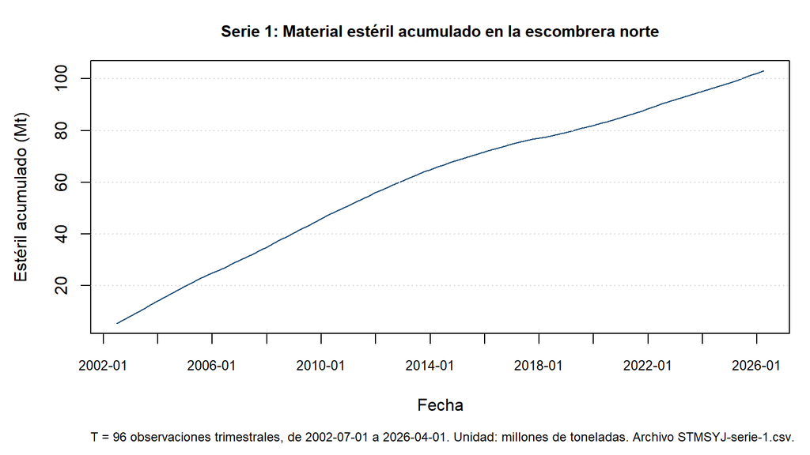

Serie 1, estéril acumulado en la escombrera norte. T = 96 observaciones trimestrales.

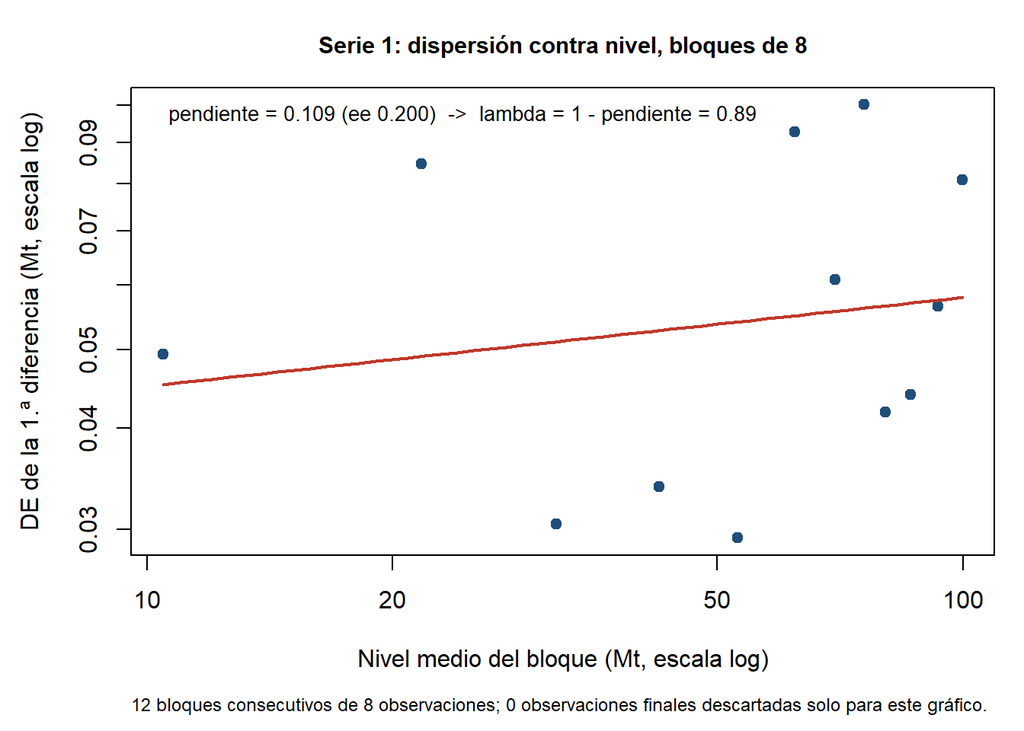

Serie 1: DE de la primera diferencia contra nivel medio, 12 bloques de 8 trimestres. T = 96.

La pendiente estimada es 0,109 (error estándar 0,200), de modo que $\lambda \approx$ 0,89. La dispersión de lo que se deposita cada trimestre no crece con el inventario acumulado, lo cual tiene sentido físico: el estéril que se deposita depende del plan de minado, no de cuánto hay ya en la escombrera. El gráfico apunta a $\lambda = 1$.

### 3.1.2 Serie 2

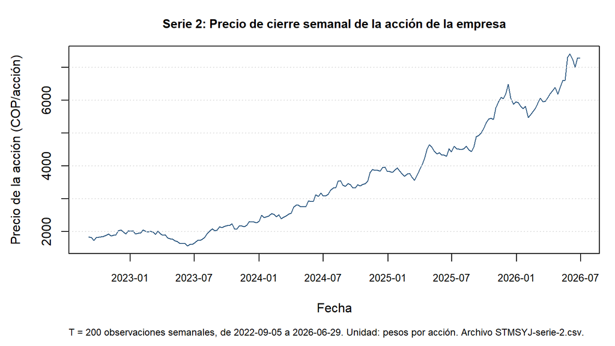

Serie 2, precio de cierre semanal de la acción. T = 200 observaciones semanales.

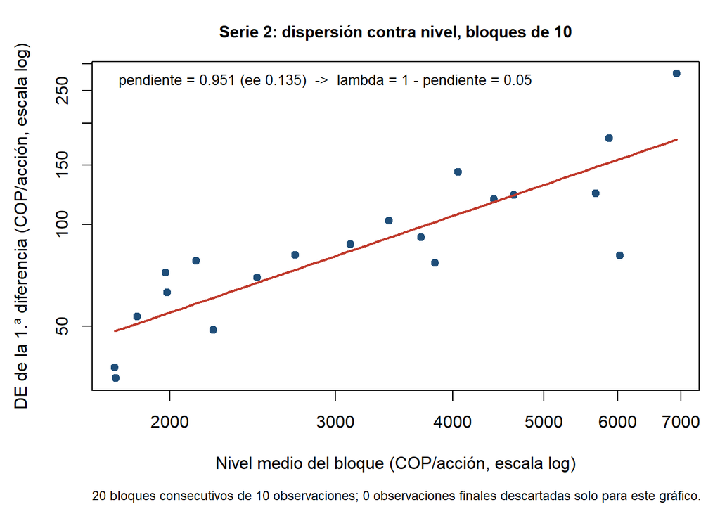

Serie 2: DE de la primera diferencia contra nivel medio, 20 bloques de 10 semanas. T = 200.

La pendiente es 0,951 (ee 0,135), así que $\lambda \approx$ 0,05: la variación semanal en pesos es proporcional al precio, como se espera de un precio cuyos choques son porcentuales. El gráfico apunta al logaritmo.

### 3.1.3 Serie 3

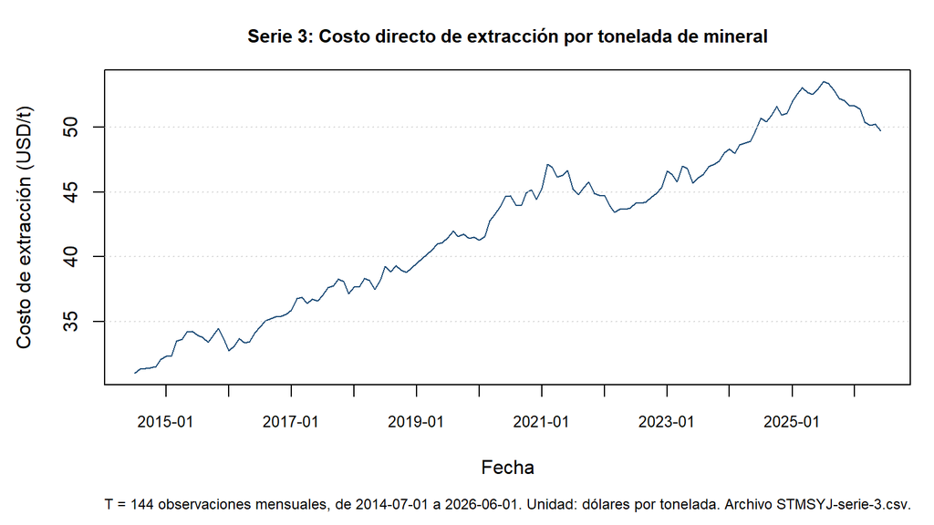

Serie 3, costo directo de extracción por tonelada. T = 144 observaciones mensuales.

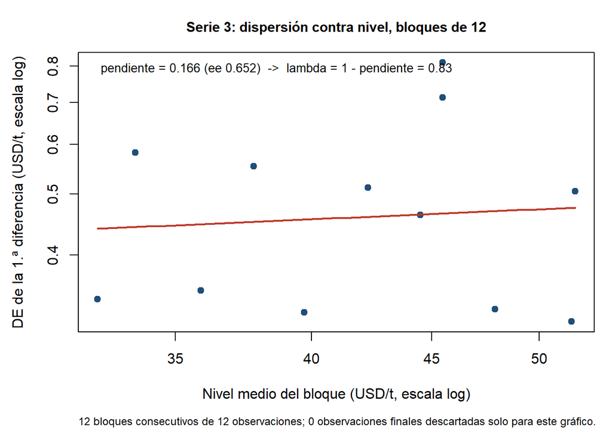

Serie 3: DE de la primera diferencia contra nivel medio, 12 bloques de 12 meses. T = 144.

La pendiente es 0,166 con un error estándar de 0,652, mucho mayor que la propia pendiente, de modo que $\lambda \approx$ 0,83 es muy impreciso. El nivel solo recorre de 31,02 a 53,54 USD/t (un cociente de 1,73), un rango demasiado corto para que el gráfico distinga una relación entre dispersión y nivel. Este gráfico no decide la transformación de la serie 3; la decide el perfil de la sección 3.2.

Sensibilidad de la pendiente al tamaño del bloque.

| Serie | k (obs. por bloque) | Bloques | Pendiente | λ = 1 − pendiente |
| --- | --- | --- | --- | --- |
| 1 | 6 | 16 | -0,017 | 1,02 |
| 1 | 8 | 12 | 0,109 | 0,89 |
| 1 | 12 | 8 | 0,131 | 0,87 |
| 2 | 8 | 25 | 1,107 | -0,11 |
| 2 | 10 | 20 | 0,951 | 0,05 |
| 2 | 20 | 10 | 1,022 | -0,02 |
| 3 | 8 | 18 | 0,964 | 0,04 |
| 3 | 12 | 12 | 0,166 | 0,83 |
| 3 | 18 | 8 | 0,527 | 0,47 |

La lectura es estable en las series 1 ($\lambda$ cerca de 1) y 2 ($\lambda$ cerca de 0) y cambia de un extremo al otro en la serie 3, lo que confirma que allí el gráfico no tiene información suficiente.

## 3.2 Perfil de log-verosimilitud de λ

Las tres series toman solo valores positivos (columna «Valores > 0» de la tabla de verificación), de modo que la familia de Box y Cox, $g_\lambda(Z) = (Z^\lambda - 1)/\lambda$ con $g_0(Z) = \ln Z$, se aplica tal cual.

**Con qué modelo se calculó la verosimilitud y por qué.** La verosimilitud gaussiana exige un modelo estacionario para la serie transformada, y ninguna de las tres lo es en nivel. Se usó el mismo modelo de trabajo en las tres: la primera diferencia $W_t = (1-B)\,g_\lambda(Z_t)$, $t = 2,\dots,T$, como un AR(1) con media,
$$W_t - \mu = \phi\,(W_{t-1}-\mu) + a_t,\qquad a_t \sim N(0,\sigma^2),$$
estimado por máxima verosimilitud exacta. La diferencia quita la tendencia estocástica, la media $\mu$ recoge la deriva y el AR(1) absorbe la autocorrelación de corto plazo. Ese último término es necesario: en la serie 1 la diferencia es muy persistente ($\hat\phi$ = 0,984), y con una caminata aleatoria con deriva el residuo autocorrelacionado distorsiona el perfil y lleva $\hat\lambda$ a 1,32, fuera del intervalo de los demás modelos (tabla de sensibilidad abajo). El modelo de trabajo no es el modelo final; solo debe dejar residuos aproximadamente blancos para que $\lambda$ responda a la varianza y no a la estructura de la media.

La log-verosimilitud de $Z_2,\dots,Z_T$ dado $Z_1$ es la de $W$ más el jacobiano de la transformación,
$$\ell(\lambda) = \ell_W\big(\hat\phi,\hat\mu,\hat\sigma^2;\lambda\big) + (\lambda-1)\sum_{t=2}^{T}\ln Z_t,$$
sin el cual los perfiles de distintos $\lambda$ no serían comparables, porque cada uno mide la serie en una escala diferente. El intervalo de confianza del 95 % es el de razón de verosimilitudes, $\{\lambda : \ell(\lambda) \ge \ell(\hat\lambda) - \tfrac12\chi^2_{1;0,95}\}$, con $\tfrac12\chi^2_{1;0,95} = 1,921$.

**Regla para redondear.** Dentro del intervalo se prefiere $\lambda = 1$, que deja la serie en su unidad; si 1 no está, $\lambda = 0$, cuya diferencia es un cambio porcentual; y si ninguno está, el múltiplo de 0,5 más cercano a $\hat\lambda$.

Perfil de λ con el jacobiano: máximo, intervalo y valor elegido.

| Serie | λ̂ | IC 95 % | φ̂ del modelo de trabajo en λ̂ | λ elegido | Razón |
| --- | --- | --- | --- | --- | --- |
| 1 | 1,042 | [0,927; 1,179] | 0,984 | 1 | 1 está en el intervalo: no se transforma |
| 2 | 0,006 | [-0,205; 0,213] | 0,029 | 0 | 0 está en el intervalo y 1 no: logaritmo |
| 3 | 0,305 | [-0,478; 1,114] | 0,088 | 1 | 1 está en el intervalo: no se transforma |

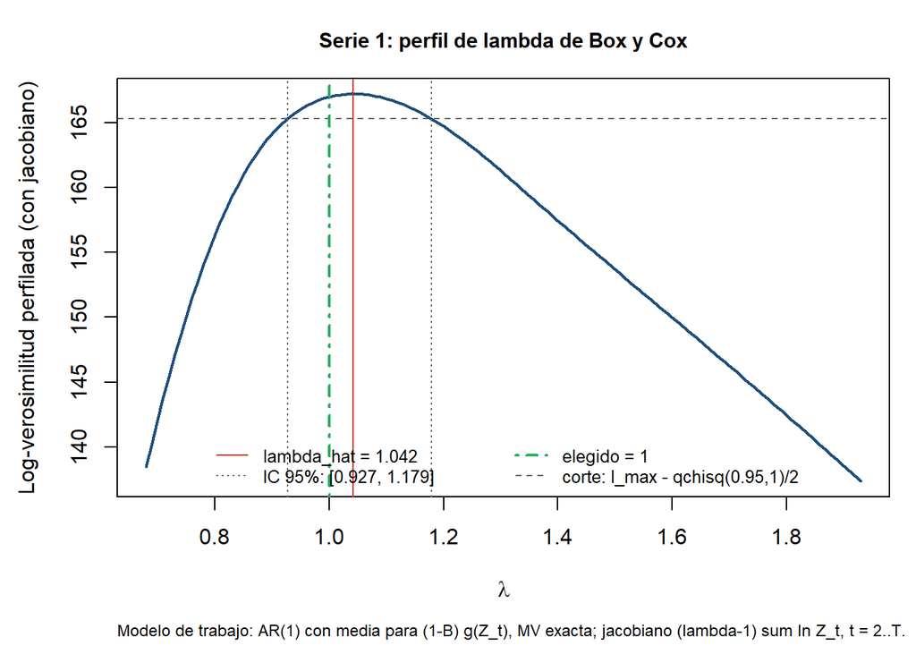

Serie 1: perfil de log-verosimilitud de λ.

**Serie 1.** $\hat\lambda$ = 1,042, con intervalo [0,927; 1,179]. El intervalo es estrecho, contiene a 1 y excluye a 0 y a 0,5. Se elige $\lambda = 1$, de acuerdo con el gráfico de dispersión contra nivel: la serie no se transforma.

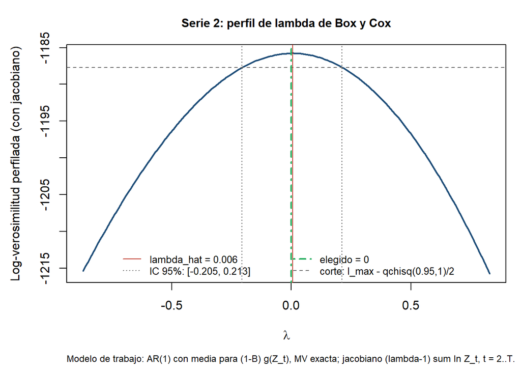

Serie 2: perfil de log-verosimilitud de λ.

**Serie 2.** $\hat\lambda$ = 0,006, con intervalo [-0,205; 0,213]. El intervalo excluye a 1 (no transformar está claramente rechazado) y contiene a 0. Se elige $\lambda = 0$, el logaritmo, que además coincide con la pendiente cercana a 1 del gráfico de dispersión contra nivel.

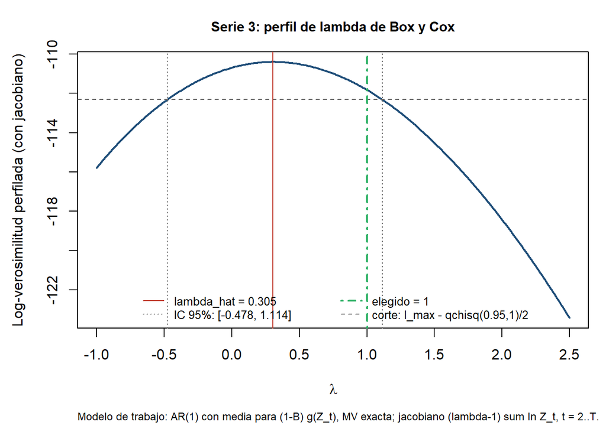

Serie 3: perfil de log-verosimilitud de λ.

**Serie 3.** $\hat\lambda$ = 0,305, con un intervalo amplio, [-0,478; 1,114], que contiene a la vez a 0, a 0,5 y a 1. Los datos no distinguen entre esas transformaciones: la log-verosimilitud en $\lambda = 1$ queda a 1,43 unidades del máximo, por debajo del corte de 1,921. La razón es el rango corto del nivel: entre 31,02 y 53,54 USD/t cualquier potencia es casi lineal (la correlación entre $Z_t$ y $g_{\hat\lambda}(Z_t)$ es 0,9988). Se elige $\lambda = 1$: está dentro del intervalo, es el valor más simple y deja la serie en dólares por tonelada, que es la unidad en la cual el contexto mide la pérdida (cerca de 1,1 millones de dólares al mes por cada dólar de error). Notamos que 1 está cerca del extremo superior del intervalo; si la validación de la sección 7 mostrara residuos cuya dispersión crece con el nivel, la alternativa sería $\lambda = 0$.

**Sensibilidad al modelo de trabajo.** Se repitió el perfil con otros modelos para la serie diferenciada, con `stats::arima()` y el jacobiano de las $T-d$ observaciones que entran en cada verosimilitud.

λ̂ e intervalo con distintos modelos de trabajo.

| Serie | Modelo de trabajo | λ̂ (rejilla de 0,02) | IC 95 % |
| --- | --- | --- | --- |
| 1 | ARIMA(0,1,0) con constante | 1,32 | [1,26; 1,38] |
| 1 | ARIMA(1,1,0) con constante | 1,04 | [0,94; 1,16] |
| 1 | ARIMA(2,1,0) con constante | 1,04 | [0,90; 1,20] |
| 1 | ARIMA(1,2,0) | 1,00 | [0,88; 1,16] |
| 1 | ARIMA(0,2,1) | 1,00 | [0,90; 1,16] |
| 2 | ARIMA(0,1,0) con constante | 0,00 | [-0,20; 0,20] |
| 2 | ARIMA(1,1,0) con constante | 0,00 | [-0,20; 0,20] |
| 2 | ARIMA(2,1,0) con constante | 0,02 | [-0,20; 0,20] |
| 2 | ARIMA(1,2,0) | 0,00 | [-0,20; 0,20] |
| 2 | ARIMA(0,2,1) | 0,00 | [-0,20; 0,20] |
| 3 | ARIMA(0,1,0) con constante | 0,30 | [-0,48; 1,08] |
| 3 | ARIMA(1,1,0) con constante | 0,30 | [-0,46; 1,10] |
| 3 | ARIMA(2,1,0) con constante | 0,34 | [-0,42; 1,14] |
| 3 | ARIMA(1,2,0) | 0,36 | [-0,44; 1,20] |
| 3 | ARIMA(0,2,1) | 0,32 | [-0,46; 1,14] |

Con cualquier modelo que absorba la autocorrelación de la diferencia, la elección no cambia: $\lambda = 1$ en la serie 1, $\lambda = 0$ en la serie 2 y un intervalo que contiene a 1 en la serie 3. La única diferencia es la caminata aleatoria con deriva en la serie 1, que ignora la fuerte persistencia de $\nabla Z_t$ y por eso no sirve como modelo de trabajo para esa serie.

**Verificación del perfil propio.** El perfil se calcula con una implementación propia en R base (`loglik_ar1_exacta()` y `perfil_lambda()`, en `R/01-transformacion.R`). En tres valores de $\lambda$ se contrasta con la log-verosimilitud que reporta `arima(diff(g), order = c(1, 0, 0), include.mean = TRUE, method = "ML")` sobre la serie transformada y diferenciada, más el mismo jacobiano:

Contraste del perfil propio contra stats::arima().

| Serie | λ | ℓ(λ) propia | arima() + jacobiano | Diferencia |
| --- | --- | --- | --- | --- |
| 1 | 0,0 | -36,537 | -36,537 | 2.3e-09 |
| 1 | 0,5 | 97,415 | 97,415 | 3.4e-11 |
| 1 | 1,0 | 167,014 | 167,014 | 3.6e-12 |
| 2 | 0,0 | -1.185,786 | -1.185,786 | 2.3e-13 |
| 2 | 0,5 | -1.196,744 | -1.196,744 | 4.5e-13 |
| 2 | 1,0 | -1.228,748 | -1.228,748 | 1.1e-12 |
| 3 | 0,0 | -110,688 | -110,688 | 3.9e-12 |
| 3 | 0,5 | -110,514 | -110,514 | 7.7e-13 |
| 3 | 1,0 | -111,826 | -111,826 | 9.7e-13 |

Las diferencias son del orden de $10^{-9}$ o menores: la implementación propia reproduce la verosimilitud exacta de `arima()`.

## 3.3 Qué representan la serie transformada y su diferencia

**Serie 1 ($\lambda = 1$).** $g(Z_t) = Z_t$ es el inventario de estéril acumulado, en Mt. Su primera diferencia $\nabla Z_t$ es el estéril depositado durante el trimestre t, en Mt por trimestre (entre 0,48 y 1,52, 0,89 en promedio en los últimos dos años). Si la serie necesitara una segunda diferencia, $\nabla^2 Z_t$ sería el cambio en el ritmo de depósito de un trimestre al siguiente.

**Serie 2 ($\lambda = 0$).** $g(Z_t) = \ln Z_t$ es el logaritmo del precio. Su diferencia $\nabla \ln Z_t = \ln(Z_t/Z_{t-1})$ es el rendimiento logarítmico semanal, y $100\,\nabla \ln Z_t$ aproxima la variación porcentual del precio en la semana, $100\,(Z_t - Z_{t-1})/Z_{t-1}$, con buena precisión cuando la variación es pequeña. En la muestra, el rendimiento semanal medio es 0,69 % y su desviación estándar 2,93 %. En esta escala, un choque mueve el precio en un porcentaje, no en un número fijo de pesos, que es lo que muestra el gráfico de dispersión contra nivel.

**Serie 3 ($\lambda = 1$).** $g(Z_t) = Z_t$ es el costo directo por tonelada, en USD/t. Su diferencia $\nabla Z_t$ es el cambio del costo de un mes al siguiente, en USD/t por mes; por la regla del contexto, un cambio de un dólar no anticipado equivale a cerca de 1,1 millones de dólares al mes de mineral mal clasificado.

# 4 Orden de integración

Todo el trabajo de esta sección se hace sobre la serie transformada elegida en la sección 3: $g(Z_t) = Z_t$ en la serie 1, $\ln Z_t$ en la serie 2 y $Z_t$ en la serie 3. El código está en `R/02-integracion.R`.

## 4.1 Varianza, r₁ y ACF de las diferencias

Varianza muestral y autocorrelaciones de g(Z_t) y de sus diferencias. ∇³g se incluye solo para mostrar que una diferencia más ya es excesiva.

| Serie | Diferencia | n | Varianza muestral | r₁ | r₂ |  |
| --- | --- | --- | --- | --- | --- | --- |
| 1 | g | 96 | 782 | 0,967 | 0,933 |  |
| 1 | ∇g | 95 | 0,0815 | 0,980 | 0,951 |  |
| 1 | ∇²g | 94 | 0,001679 | 0,383 | 0,066 | ← mínima |
| 1 | ∇³g | 93 | 0,002085 | -0,235 | -0,212 |  |
| 2 | g | 200 | 0,1999 | 0,985 | 0,970 |  |
| 2 | ∇g | 199 | 0,0008607 | 0,029 | -0,049 | ← mínima |
| 2 | ∇²g | 198 | 0,001677 | -0,461 | -0,089 |  |
| 2 | ∇³g | 197 | 0,004911 | -0,619 | 0,076 |  |
| 3 | g | 144 | 40,59 | 0,981 | 0,960 |  |
| 3 | ∇g | 143 | 0,2842 | 0,093 | -0,281 | ← mínima |
| 3 | ∇²g | 142 | 0,5161 | -0,290 | -0,477 |  |
| 3 | ∇³g | 141 | 1,338 | -0,425 | -0,365 |  |

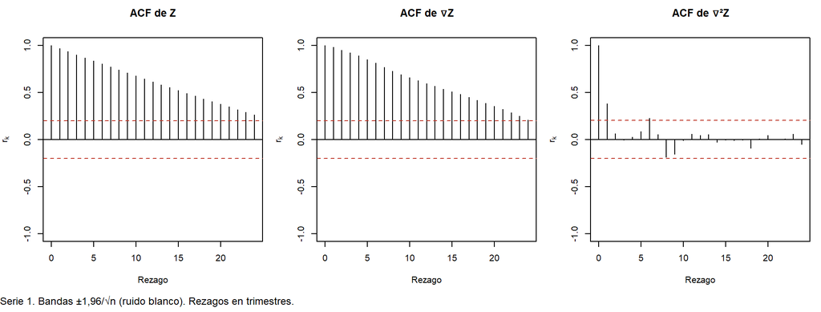

Serie 1: ACF muestral de Z, ∇Z y ∇²Z.

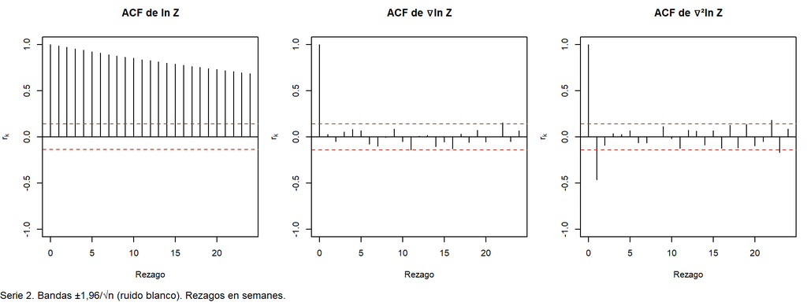

Serie 2: ACF muestral de ln Z, ∇ln Z y ∇²ln Z.

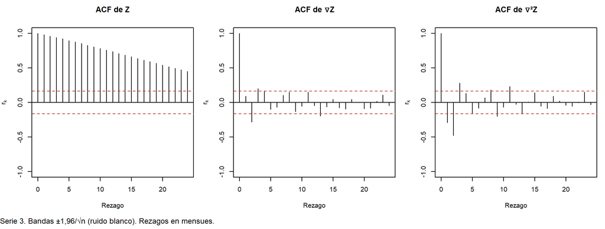

Serie 3: ACF muestral de Z, ∇Z y ∇²Z.

Las dos piezas se leen con dos reglas del curso. La primera es la de la **varianza mínima**: diferenciar una serie no estacionaria reduce su varianza, y diferenciar una que ya es estacionaria la aumenta, porque si $W_t$ es estacionaria, $\operatorname{Var}(\nabla W_t) = 2\gamma_0(1-\rho_1)$, que supera $\gamma_0$ siempre que $\rho_1 < 1/2$. La segunda es la **forma de la ACF**: la de una serie no estacionaria arranca cerca de 1 y decae lento y casi en línea recta, mientras que la de una serie sobrediferenciada tiene un $r_1$ negativo cercano a $-0{,}5$, la huella de la raíz unitaria que una diferencia de más introduce en la parte MA.

**Serie 1.** La ACF de $Z_t$ y la de $\nabla Z_t$ decaen igual de lento (r₁ = 0,967 y 0,980): el estéril depositado por trimestre tampoco es estacionario. La de $\nabla^2 Z_t$ se corta tras el rezago 1 (r₁ = 0,383). La varianza cae de 0,0815 a 0,001679 con la segunda diferencia y sube a 0,002085 con la tercera. Las dos reglas sugieren **d = 2**. La segunda diferencia no es excesiva: la varianza es mínima en d = 2, y el r₁ de $\nabla^2 Z_t$ es positivo, no cercano a $-0{,}5$.

**Serie 2.** La ACF de $\ln Z_t$ decae lento desde r₁ = 0,985. La de $\nabla \ln Z_t$ no tiene ningún valor importante (r₁ = 0,029), y la varianza es mínima en d = 1. Con una diferencia más, la varianza casi se duplica (de 0,0008607 a 0,001677) y r₁ cae a -0,461, la señal típica de sobrediferenciación. Las dos reglas sugieren **d = 1**, y una sola diferencia no es excesiva.

**Serie 3.** La ACF de $Z_t$ decae lento desde r₁ = 0,981, y la de $\nabla Z_t$ tiene valores de corto plazo y se apaga. La varianza es mínima en d = 1 (0,2842). La segunda diferencia la aumenta a 0,5161 y vuelve negativo a r₁ (-0,290). Las reglas sugieren **d = 1**. La diferencia no es excesiva: el r₁ de $\nabla Z_t$ es 0,093, lejos de $-0{,}5$.

## 4.2 Pruebas de Dickey y Fuller aumentadas

**Implementación.** La regresión de Dickey y Fuller aumentada,
$$\nabla y_t = \beta_0 + \beta_1 t + \gamma\, y_{t-1} + \sum_{j=1}^{p}\delta_j \nabla y_{t-j} + e_t,$$
la estima el equipo en R base por mínimos cuadrados (`adf_propia()`). $\beta_0$ y $\beta_1 t$ entran o no según la especificación. La raíz unitaria corresponde a $\gamma = 0$ y la alterna estacionaria a $\gamma < 0$.

**Rezagos.** El número de rezagos $p$ se elige con el criterio de Schwarz (BIC) entre $p = 0, \dots, p_{\max}$, con $p_{\max} = \lfloor 12\,(n/100)^{1/4}\rfloor$ (regla de Schwert, 1989): 11 en la serie 1, 14 en la serie 2 y 13 en la serie 3. Todos los $p$ se comparan sobre la misma muestra, la que permite $p_{\max}$ rezagos, y la prueba se estima después con el $p$ elegido sobre la muestra más larga posible. El BIC penaliza más que el AIC; los rezagos solo se agregan para que $e_t$ quede sin autocorrelación, y con $p$ de más la prueba pierde potencia.

**Valores críticos.** Bajo $H_0$, $\hat\tau$ no sigue una $t$ de Student. Su distribución depende de la especificación determinista, y los valores críticos salen de la tabla de Fuller (1976, tabla 8.5.2), reproducida en Hamilton (1994, tabla B.6), para el tamaño de muestra efectivo. Son los que entrega `urca::ur.df()`. El valor p es la aproximación de MacKinnon (1996), calculada con `urca::punitroot()`.

**Especificación determinista.** Se justifica con los gráficos en el tiempo de $g$, $\nabla g$ y $\nabla^2 g$:

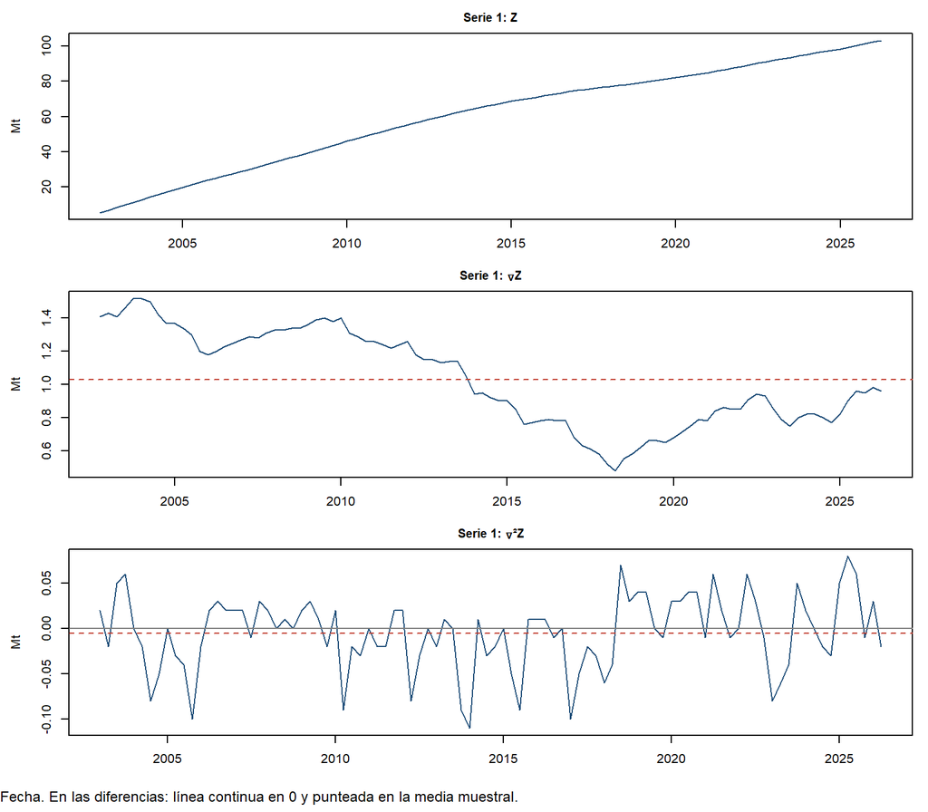

Serie 1: Z, ∇Z y ∇²Z en el tiempo.

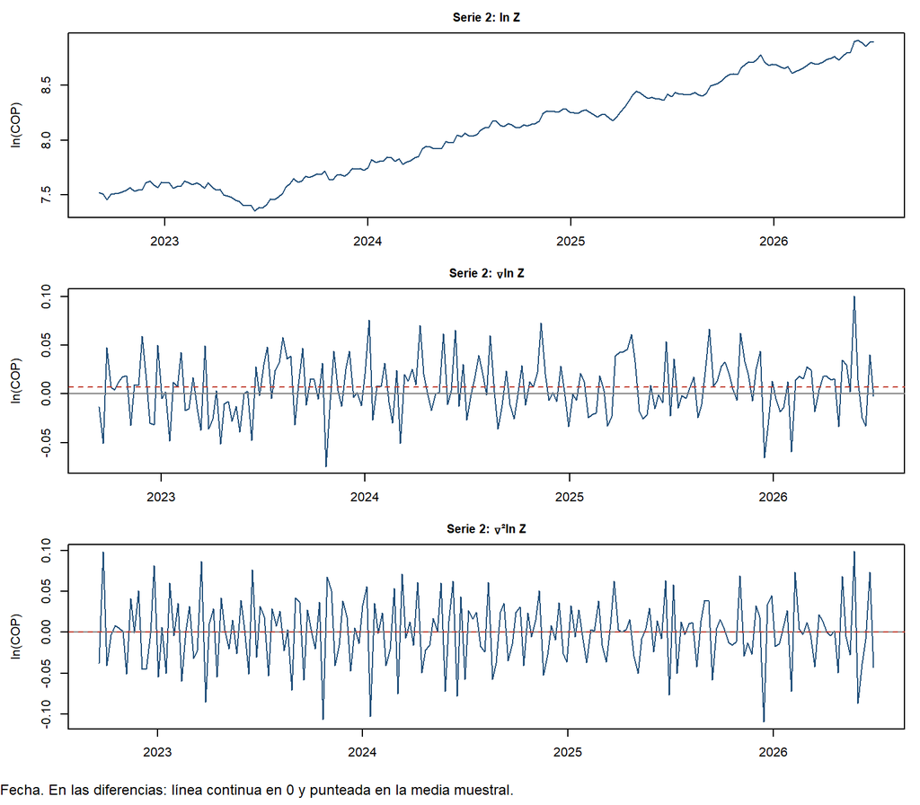

Serie 2: ln Z, ∇ln Z y ∇²ln Z en el tiempo.

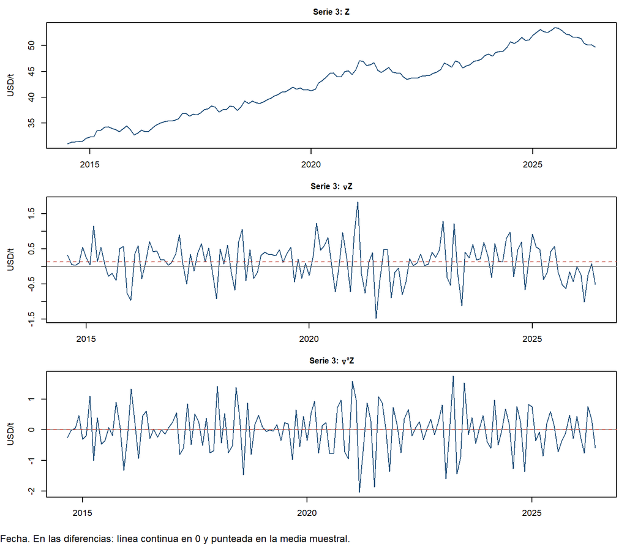

Serie 3: Z, ∇Z y ∇²Z en el tiempo.

- $g(Z_t)$, en las tres series, crece a lo largo de toda la muestra. Bajo la alterna, la serie sería estacionaria alrededor de una recta, así que la prueba se hace **con constante y tendencia**. Sin la tendencia, la prueba no tendría potencia contra esa alterna.
- $\nabla g$ oscila alrededor de una media distinta de cero (el estéril depositado por trimestre, el rendimiento semanal medio y el aumento mensual medio del costo) y no muestra una recta, así que se usa **con constante**.
- $\nabla^2 Z_t$ de la serie 1 oscila alrededor de cero, así que se usa **sin constante**.

**Estrategia secuencial.** Se prueba primero sobre $g$, después sobre $\nabla g$ y, si hace falta, sobre $\nabla^2 g$. La secuencia se detiene en la primera serie en la que se rechaza la raíz unitaria.

Pruebas de Dickey y Fuller aumentadas en estrategia secuencial (rezagos por BIC).

| Serie | Sobre | Especificación | p | n ef. | γ̂ | τ̂ | VC 5 % | Valor p | Decisión |
| --- | --- | --- | --- | --- | --- | --- | --- | --- | --- |
| 1 | g | constante y tendencia | 2 | 93 | -0,0027 | -2,347 | -3,45 | 0,4046 | no rechaza H0 |
| 1 | ∇g | constante | 1 | 93 | -0,0214 | -1,550 | -2,89 | 0,5038 | no rechaza H0 |
| 1 | ∇²g | sin constante | 0 | 93 | -0,6073 | -6,334 | -1,95 | 2.0e-10 | rechaza H0 |
| 2 | g | constante y tendencia | 0 | 199 | -0,0564 | -2,640 | -3,43 | 0,2631 | no rechaza H0 |
| 2 | ∇g | constante | 0 | 198 | -0,9709 | -13,611 | -2,88 | 7.9e-23 | rechaza H0 |
| 3 | g | constante y tendencia | 3 | 140 | -0,0810 | -2,207 | -3,43 | 0,4817 | no rechaza H0 |
| 3 | ∇g | constante | 2 | 140 | -0,8250 | -5,719 | -2,88 | 2.1e-06 | rechaza H0 |

A continuación van las pruebas con sus seis elementos.

### 4.2.1 Serie 1

Prueba sobre $Z_t$, con la especificación con constante y tendencia (caso 4, $\tau_\tau$), con $p = 2$ rezagos (BIC sobre $p = 0,\dots,11$) y $n_{ef} = 93$:

1. **Hipótesis.** $H_0: \gamma = 0$ (raíz unitaria) frente a $H_1: \gamma < 0$, en $\nabla y_t = \beta_0 + \beta_1 t + \gamma y_{t-1} + \sum_{j=1}^{2}\delta_j \nabla y_{t-j} + e_t$.
2. **Estadístico.** $\hat\tau = \hat\gamma / \widehat{\text{ee}}(\hat\gamma)$; bajo $H_0$ no sigue una $t$ sino la distribución de Dickey y Fuller para la especificación con constante y tendencia (caso 4, $\tau_\tau$). Valores críticos de Fuller (1976, tabla 8.5.2; Hamilton, 1994, tabla B.6) para el tamaño de muestra: 1 % = -4,04, 5 % = -3,45, 10 % = -3,15.
3. **Región de rechazo al 5 %.** $\hat\tau < -3,45$.
4. **Valor observado.** $\hat\gamma = -0,0027$, ee $= 0,0011$, $\hat\tau = -2,347$; valor p aproximado de MacKinnon (1996) = 0,4046.
5. **Decisión.** No se rechaza $H_0$ al 5 %.
6. **Lectura.** No hay evidencia contra la raíz unitaria en $Z_t$: se diferencia y se prueba de nuevo.

Prueba sobre $\nabla Z_t$, con la especificación con constante (caso 2, $\tau_\mu$), con $p = 1$ rezagos (BIC sobre $p = 0,\dots,11$) y $n_{ef} = 93$:

1. **Hipótesis.** $H_0: \gamma = 0$ (raíz unitaria) frente a $H_1: \gamma < 0$, en $\nabla y_t = \beta_0 + \gamma y_{t-1} + \sum_{j=1}^{1}\delta_j \nabla y_{t-j} + e_t$.
2. **Estadístico.** $\hat\tau = \hat\gamma / \widehat{\text{ee}}(\hat\gamma)$; bajo $H_0$ no sigue una $t$ sino la distribución de Dickey y Fuller para la especificación con constante (caso 2, $\tau_\mu$). Valores críticos de Fuller (1976, tabla 8.5.2; Hamilton, 1994, tabla B.6) para el tamaño de muestra: 1 % = -3,51, 5 % = -2,89, 10 % = -2,58.
3. **Región de rechazo al 5 %.** $\hat\tau < -2,89$.
4. **Valor observado.** $\hat\gamma = -0,0214$, ee $= 0,0138$, $\hat\tau = -1,550$; valor p aproximado de MacKinnon (1996) = 0,5038.
5. **Decisión.** No se rechaza $H_0$ al 5 %.
6. **Lectura.** No hay evidencia contra la raíz unitaria en $\nabla Z_t$: se diferencia y se prueba de nuevo.

Prueba sobre $\nabla^2 Z_t$, con la especificación sin constante (caso 1, $\tau$), con $p = 0$ rezagos (BIC sobre $p = 0,\dots,11$) y $n_{ef} = 93$:

1. **Hipótesis.** $H_0: \gamma = 0$ (raíz unitaria) frente a $H_1: \gamma < 0$, en $\nabla y_t = \gamma y_{t-1} + e_t$.
2. **Estadístico.** $\hat\tau = \hat\gamma / \widehat{\text{ee}}(\hat\gamma)$; bajo $H_0$ no sigue una $t$ sino la distribución de Dickey y Fuller para la especificación sin constante (caso 1, $\tau$). Valores críticos de Fuller (1976, tabla 8.5.2; Hamilton, 1994, tabla B.6) para el tamaño de muestra: 1 % = -2,60, 5 % = -1,95, 10 % = -1,61.
3. **Región de rechazo al 5 %.** $\hat\tau < -1,95$.
4. **Valor observado.** $\hat\gamma = -0,6073$, ee $= 0,0959$, $\hat\tau = -6,334$; valor p aproximado de MacKinnon (1996) = $2,0 \times 10^{-10}$.
5. **Decisión.** Se rechaza $H_0$ al 5 %.
6. **Lectura.** $\nabla^2 Z_t$ no tiene raíz unitaria: es estacionaria alrededor de cero, y no necesita otra diferencia.

### 4.2.2 Serie 2

Prueba sobre $\ln Z_t$, con la especificación con constante y tendencia (caso 4, $\tau_\tau$), con $p = 0$ rezagos (BIC sobre $p = 0,\dots,14$) y $n_{ef} = 199$:

1. **Hipótesis.** $H_0: \gamma = 0$ (raíz unitaria) frente a $H_1: \gamma < 0$, en $\nabla y_t = \beta_0 + \beta_1 t + \gamma y_{t-1} + e_t$.
2. **Estadístico.** $\hat\tau = \hat\gamma / \widehat{\text{ee}}(\hat\gamma)$; bajo $H_0$ no sigue una $t$ sino la distribución de Dickey y Fuller para la especificación con constante y tendencia (caso 4, $\tau_\tau$). Valores críticos de Fuller (1976, tabla 8.5.2; Hamilton, 1994, tabla B.6) para el tamaño de muestra: 1 % = -3,99, 5 % = -3,43, 10 % = -3,13.
3. **Región de rechazo al 5 %.** $\hat\tau < -3,43$.
4. **Valor observado.** $\hat\gamma = -0,0564$, ee $= 0,0214$, $\hat\tau = -2,640$; valor p aproximado de MacKinnon (1996) = 0,2631.
5. **Decisión.** No se rechaza $H_0$ al 5 %.
6. **Lectura.** No hay evidencia contra la raíz unitaria en $\ln Z_t$: se diferencia y se prueba de nuevo.

Prueba sobre $\nabla \ln Z_t$, con la especificación con constante (caso 2, $\tau_\mu$), con $p = 0$ rezagos (BIC sobre $p = 0,\dots,14$) y $n_{ef} = 198$:

1. **Hipótesis.** $H_0: \gamma = 0$ (raíz unitaria) frente a $H_1: \gamma < 0$, en $\nabla y_t = \beta_0 + \gamma y_{t-1} + e_t$.
2. **Estadístico.** $\hat\tau = \hat\gamma / \widehat{\text{ee}}(\hat\gamma)$; bajo $H_0$ no sigue una $t$ sino la distribución de Dickey y Fuller para la especificación con constante (caso 2, $\tau_\mu$). Valores críticos de Fuller (1976, tabla 8.5.2; Hamilton, 1994, tabla B.6) para el tamaño de muestra: 1 % = -3,46, 5 % = -2,88, 10 % = -2,57.
3. **Región de rechazo al 5 %.** $\hat\tau < -2,88$.
4. **Valor observado.** $\hat\gamma = -0,9709$, ee $= 0,0713$, $\hat\tau = -13,611$; valor p aproximado de MacKinnon (1996) = $7,9 \times 10^{-23}$.
5. **Decisión.** Se rechaza $H_0$ al 5 %.
6. **Lectura.** $\nabla \ln Z_t$ no tiene raíz unitaria: es estacionaria alrededor de una media, y no necesita otra diferencia.

### 4.2.3 Serie 3

Prueba sobre $Z_t$, con la especificación con constante y tendencia (caso 4, $\tau_\tau$), con $p = 3$ rezagos (BIC sobre $p = 0,\dots,13$) y $n_{ef} = 140$:

1. **Hipótesis.** $H_0: \gamma = 0$ (raíz unitaria) frente a $H_1: \gamma < 0$, en $\nabla y_t = \beta_0 + \beta_1 t + \gamma y_{t-1} + \sum_{j=1}^{3}\delta_j \nabla y_{t-j} + e_t$.
2. **Estadístico.** $\hat\tau = \hat\gamma / \widehat{\text{ee}}(\hat\gamma)$; bajo $H_0$ no sigue una $t$ sino la distribución de Dickey y Fuller para la especificación con constante y tendencia (caso 4, $\tau_\tau$). Valores críticos de Fuller (1976, tabla 8.5.2; Hamilton, 1994, tabla B.6) para el tamaño de muestra: 1 % = -3,99, 5 % = -3,43, 10 % = -3,13.
3. **Región de rechazo al 5 %.** $\hat\tau < -3,43$.
4. **Valor observado.** $\hat\gamma = -0,0810$, ee $= 0,0367$, $\hat\tau = -2,207$; valor p aproximado de MacKinnon (1996) = 0,4817.
5. **Decisión.** No se rechaza $H_0$ al 5 %.
6. **Lectura.** No hay evidencia contra la raíz unitaria en $Z_t$: se diferencia y se prueba de nuevo.

Prueba sobre $\nabla Z_t$, con la especificación con constante (caso 2, $\tau_\mu$), con $p = 2$ rezagos (BIC sobre $p = 0,\dots,13$) y $n_{ef} = 140$:

1. **Hipótesis.** $H_0: \gamma = 0$ (raíz unitaria) frente a $H_1: \gamma < 0$, en $\nabla y_t = \beta_0 + \gamma y_{t-1} + \sum_{j=1}^{2}\delta_j \nabla y_{t-j} + e_t$.
2. **Estadístico.** $\hat\tau = \hat\gamma / \widehat{\text{ee}}(\hat\gamma)$; bajo $H_0$ no sigue una $t$ sino la distribución de Dickey y Fuller para la especificación con constante (caso 2, $\tau_\mu$). Valores críticos de Fuller (1976, tabla 8.5.2; Hamilton, 1994, tabla B.6) para el tamaño de muestra: 1 % = -3,46, 5 % = -2,88, 10 % = -2,57.
3. **Región de rechazo al 5 %.** $\hat\tau < -2,88$.
4. **Valor observado.** $\hat\gamma = -0,8250$, ee $= 0,1443$, $\hat\tau = -5,719$; valor p aproximado de MacKinnon (1996) = $2,1 \times 10^{-6}$.
5. **Decisión.** Se rechaza $H_0$ al 5 %.
6. **Lectura.** $\nabla Z_t$ no tiene raíz unitaria: es estacionaria alrededor de una media, y no necesita otra diferencia.

**Sensibilidad.** La tabla siguiente repite cada prueba con las tres especificaciones y con AIC en lugar de BIC. Ninguna combinación cambia la decisión de la estrategia secuencial. En las tres series, $g$ no rechaza la raíz unitaria con ninguna especificación. En la serie 1, $\nabla Z_t$ tampoco la rechaza, y $\nabla^2 Z_t$ la rechaza con todas.

Sensibilidad de τ̂ a la especificación y al criterio de rezagos.

| Serie | Sobre | Especificación | τ̂ (BIC) | τ̂ (AIC) | VC 5 % |
| --- | --- | --- | --- | --- | --- |
| 1 | g | sin constante | 0,84 (p=2) | 0,84 (p=2) | -1,95 |
| 1 | g | constante | -0,98 (p=2) | -0,98 (p=2) | -2,89 |
| 1 | g | constante y tendencia | -2,35 (p=2) | -2,46 (p=9) | -3,45 |
| 1 | ∇g | sin constante | -1,21 (p=1) | -1,21 (p=1) | -1,95 |
| 1 | ∇g | constante | -1,55 (p=1) | -1,55 (p=1) | -2,89 |
| 1 | ∇g | constante y tendencia | -1,23 (p=1) | -1,23 (p=1) | -3,45 |
| 1 | ∇²g | sin constante | -6,33 (p=0) | -6,33 (p=0) | -1,95 |
| 1 | ∇²g | constante | -6,38 (p=0) | -6,38 (p=0) | -2,89 |
| 1 | ∇²g | constante y tendencia | -6,46 (p=0) | -6,46 (p=0) | -3,45 |
| 2 | g | sin constante | 3,34 (p=0) | 3,34 (p=0) | -1,95 |
| 2 | g | constante | 0,57 (p=0) | 0,57 (p=0) | -2,88 |
| 2 | g | constante y tendencia | -2,64 (p=0) | -2,64 (p=0) | -3,43 |
| 2 | ∇g | sin constante | -12,95 (p=0) | -12,95 (p=0) | -1,95 |
| 2 | ∇g | constante | -13,61 (p=0) | -13,61 (p=0) | -2,88 |
| 2 | ∇g | constante y tendencia | -13,65 (p=0) | -13,65 (p=0) | -3,43 |
| 2 | ∇²g | sin constante | -12,68 (p=3) | -8,20 (p=7) | -1,95 |
| 2 | ∇²g | constante | -12,65 (p=3) | -8,18 (p=7) | -2,88 |
| 2 | ∇²g | constante y tendencia | -12,61 (p=3) | -8,15 (p=7) | -3,43 |
| 3 | g | sin constante | 2,02 (p=3) | 2,02 (p=3) | -1,95 |
| 3 | g | constante | -1,45 (p=3) | -1,45 (p=3) | -2,88 |
| 3 | g | constante y tendencia | -2,21 (p=3) | -2,21 (p=3) | -3,43 |
| 3 | ∇g | sin constante | -5,16 (p=2) | -5,16 (p=2) | -1,95 |
| 3 | ∇g | constante | -5,72 (p=2) | -5,72 (p=2) | -2,88 |
| 3 | ∇g | constante y tendencia | -5,81 (p=2) | -5,81 (p=2) | -3,43 |
| 3 | ∇²g | sin constante | -12,33 (p=2) | -6,62 (p=8) | -1,95 |
| 3 | ∇²g | constante | -12,29 (p=2) | -6,65 (p=8) | -2,88 |
| 3 | ∇²g | constante y tendencia | -12,26 (p=2) | -6,62 (p=8) | -3,43 |

**Verificación de la implementación propia.** Con la misma especificación y los mismos rezagos, `urca::ur.df(y, type, lags = p, selectlags = "Fixed")` usa la misma muestra ($t = p+2, \dots, n$) y da el mismo $\hat\gamma$ y el mismo $\hat\tau$:

ADF propia contra urca::ur.df() con la misma especificación y los mismos rezagos.

| Serie | Sobre | Tipo | p | τ̂ propio | τ̂ ur.df() | Diferencia |
| --- | --- | --- | --- | --- | --- | --- |
| 1 | g | trend | 2 | -2,347116 | -2,347116 | 1.2e-14 |
| 1 | ∇g | drift | 1 | -1,550300 | -1,550300 | -2.2e-16 |
| 1 | ∇²g | none | 0 | -6,334183 | -6,334183 | 8.9e-16 |
| 2 | g | trend | 0 | -2,640149 | -2,640149 | 0.0e+00 |
| 2 | ∇g | drift | 0 | -13,611247 | -13,611247 | 0.0e+00 |
| 3 | g | trend | 3 | -2,206825 | -2,206825 | -4.4e-16 |
| 3 | ∇g | drift | 2 | -5,719415 | -5,719415 | 0.0e+00 |

La selección automática de `ur.df(selectlags = "BIC")` no se usa para decidir, por dos razones. Nunca considera $p = 0$, porque su bucle de selección empieza en un rezago. Además, después de elegir, reestima sobre la muestra común y no sobre la más larga. La función propia evita las dos cosas.

## 4.3 Número de diferencias

Decisión sobre el número de diferencias.

| Serie | g(Z_t) | d | W_t | Evidencia |
| --- | --- | --- | --- | --- |
| 1 | Z_t | 2 | ∇²Z | ADF no rechaza en Z ni en ∇Z, rechaza en ∇²Z; varianza mínima en d = 2; ACF de ∇Z no estacionaria |
| 2 | ln Z_t | 1 | ∇ln Z | ADF no rechaza en ln Z, rechaza en ∇ln Z; varianza mínima en d = 1; ∇²ln Z con r₁ ≈ −0,46 |
| 3 | Z_t | 1 | ∇Z | ADF no rechaza en Z, rechaza en ∇Z; varianza mínima en d = 1; ∇²Z con r₁ < 0 y más varianza |

**Serie 1: d = 2.** El estéril acumulado es integrado de orden 2. Eso quiere decir que el estéril que se deposita cada trimestre, $\nabla Z_t$, es él mismo no estacionario: el ritmo de depósito pasó de 1,4–1,5 Mt por trimestre al principio a menos de 0,5 en 2018 y volvió a subir cerca de 1. Lo estacionario es el cambio de ese ritmo de un trimestre al siguiente.

**Series 2 y 3: d = 1.** El logaritmo del precio y el costo por tonelada son integrados de orden 1. Lo estacionario es el rendimiento semanal en la serie 2 y el cambio mensual del costo en la serie 3.

**¿Recta o tendencia estocástica?** En ninguna serie la evidencia indica estacionariedad alrededor de una recta: la prueba con constante y tendencia sobre $g$ no rechaza la raíz unitaria (valores p de 0,4046, 0,2631 y 0,4817). Aun así, conviene dejar claro qué habría cambiado con la otra opción:

- **Quitar la recta.** Si una serie fuera estacionaria alrededor de una recta, $g(Z_t) = \beta_0 + \beta_1 t + W_t$, la recta se quitaría estimando $\beta_0$ y $\beta_1$ por regresión de $g(Z_t)$ sobre $t$, o mejor, conjuntamente con el ARMA de $W_t$ (`tendencia = TRUE` en `ajustar_modelo()`). El residuo $W_t$ se modelaría como ARMA estacionario.
- **Diferenciar en su lugar.** Si se diferenciara una serie así, $\nabla g(Z_t) = \beta_1 + (1-B)W_t$, se introduciría una raíz unitaria en la parte MA. Esa serie sobrediferenciada no es invertible, su ACF tiene un $r_1$ cercano a $-0{,}5$ y su varianza sube. Es lo que muestran las filas ∇²ln Z de la serie 2 y ∇²Z de la serie 3 en la tabla de varianzas.
- **Efecto de un choque.** Con la recta, un choque se disipa y la serie vuelve a la tendencia determinista: el efecto es transitorio y los intervalos de pronóstico tienen ancho acotado. Con la raíz unitaria, el choque desplaza el nivel de forma permanente y la incertidumbre del pronóstico crece con el horizonte.

En la unidad de cada problema, esto se lee así:

- **Serie 1.** Un trimestre con un depósito inusual cambia de forma permanente tanto el inventario como el ritmo de depósito, porque d = 2. La fecha de llenado de la escombrera se mueve con cada choque.
- **Serie 2.** Una caída del precio no se recupera por sí sola, lo cual es coherente con un mercado en el que los precios no tienen un nivel al que regresen.
- **Serie 3.** Un aumento del costo, por ejemplo del combustible, se queda: para fijar la ley de corte, el último costo observado pesa mucho más que la tendencia histórica.

## 4.4 La constante θ₀

Cuando se diferencia, el modelo es $\phi(B)W_t = \theta_0 + \theta(B)a_t$ con $W_t = \nabla^d g(Z_t)$. Como $E(W_t) = \mu_W = \theta_0/\phi(1)$, la constante es cero si y solo si $\mu_W = 0$. Se prueba entonces $H_0:\mu_W = 0$ con la media muestral $\bar W$.

Su error estándar no es $\sqrt{\hat\gamma_0/n}$, porque las $W_t$ están autocorrelacionadas. Se usa la regla del curso,
$$S_{\bar W} = \sqrt{\frac{\hat\gamma_0}{n}\left(1 + 2r_1 + 2r_2 + \dots + 2r_K\right)},$$
donde $K$ es el último rezago en que la ACF de $W_t$ es distinta de cero. $K$ se toma como el último de los primeros seis rezagos que sale de las bandas de Bartlett (`elegir_K()`): K = 1 en la serie 1, 0 en la serie 2 y 3 en la serie 3.

**Serie 1** ($W_t = \nabla^2 Z_t$):

1. **Hipótesis.** $H_0: \mu_W = 0$ (es decir, $\theta_0 = 0$) frente a $H_1: \mu_W \neq 0$, con $W_t = \nabla^2 Z_t$.
2. **Estadístico.** $t = \bar W / S_{\bar W}$, con $S_{\bar W} = \sqrt{\hat\gamma_0/n\,(1 + 2r_1 + \dots + 2r_K)}$, $K = 1$; bajo $H_0$, aproximadamente $t_{n-1} = t_{93}$ (≈ normal estándar).
3. **Región de rechazo al 5 %.** $|t| > t_{0,975;93} = 1,986$.
4. **Valor observado.** $\bar W = -0,00479$, $\hat\gamma_0 = 0,001661$, factor $= 1 + 2(0,383) = 1,766$, $S_{\bar W} = 0,00559$, $t = -0,857$, valor p $= 0,3937$.
5. **Decisión.** No se rechaza $H_0$ al 5 %.
6. **Lectura.** No hay evidencia de que la media de $W_t$, el cambio medio del ritmo de depósito de un trimestre al siguiente (en Mt por trimestre, por trimestre), sea distinta de cero: el modelo no lleva constante.

$\theta_0 = 0$: el ritmo de depósito no tiene una aceleración determinista. Una constante en un modelo con d = 2 equivaldría a una tendencia cuadrática en el inventario, que la evidencia no respalda.

**Serie 2** ($W_t = \nabla \ln Z_t$):

1. **Hipótesis.** $H_0: \mu_W = 0$ (es decir, $\theta_0 = 0$) frente a $H_1: \mu_W \neq 0$, con $W_t = \nabla \ln Z_t$.
2. **Estadístico.** $t = \bar W / S_{\bar W}$, con $S_{\bar W} = \sqrt{\hat\gamma_0/n\,(1 + 2r_1 + \dots + 2r_K)}$, $K = 0$; bajo $H_0$, aproximadamente $t_{n-1} = t_{198}$ (≈ normal estándar).
3. **Región de rechazo al 5 %.** $|t| > t_{0,975;198} = 1,972$.
4. **Valor observado.** $\bar W = 0,00689$, $\hat\gamma_0 = 0,000856$, factor $= 1 = 1,000$, $S_{\bar W} = 0,00207$, $t = 3,319$, valor p $= 0,0011$.
5. **Decisión.** Se rechaza $H_0$ al 5 %.
6. **Lectura.** La media de $W_t$ es distinta de cero: el modelo lleva constante, y $\bar W$ estima el rendimiento logarítmico medio por semana.

$\bar W$ = 0,00689 significa que el precio creció en promedio un 0,69 % por semana entre 2022 y 2026, equivalente a un factor de 1,43 por año ($e^{52\bar W}$). Si el modelo final es una caminata aleatoria con deriva, $\theta_0 = \mu_W$ es directamente esa deriva semanal.

**Serie 3** ($W_t = \nabla Z_t$):

1. **Hipótesis.** $H_0: \mu_W = 0$ (es decir, $\theta_0 = 0$) frente a $H_1: \mu_W \neq 0$, con $W_t = \nabla Z_t$.
2. **Estadístico.** $t = \bar W / S_{\bar W}$, con $S_{\bar W} = \sqrt{\hat\gamma_0/n\,(1 + 2r_1 + \dots + 2r_K)}$, $K = 3$; bajo $H_0$, aproximadamente $t_{n-1} = t_{142}$ (≈ normal estándar).
3. **Región de rechazo al 5 %.** $|t| > t_{0,975;142} = 1,977$.
4. **Valor observado.** $\bar W = 0,13077$, $\hat\gamma_0 = 0,282181$, factor $= 1 + 2(0,093 - 0,281 + 0,200) = 1,024$, $S_{\bar W} = 0,04496$, $t = 2,909$, valor p $= 0,0042$.
5. **Decisión.** Se rechaza $H_0$ al 5 %.
6. **Lectura.** La media de $W_t$ es distinta de cero: el modelo lleva constante, y $\bar W$ estima el aumento medio del costo por mes, en USD/t por mes.

El costo directo sube en promedio 0,131 USD/t por mes, cerca de 1,57 USD/t por año. Un pronóstico que ignorara esa deriva subestimaría el costo del mes siguiente en unos 0,131 USD/t, y por la regla del contexto eso equivale a cerca de 0,14 millones de dólares de mineral mal clasificado en el mes.

**Sensibilidad a K.** La decisión no cambia con ningún $K$ entre 0 y 6 en ninguna de las tres series:

Estadístico t de la media de W_t según K; valores críticos 1,986, 1,972 y 1,977.

| Serie | t (K=0) | t (K=1) | t (K=2) | t (K=3) | t (K=4) | t (K=5) | t (K=6) | Decisión |
| --- | --- | --- | --- | --- | --- | --- | --- | --- |
| 1 | -1,139 | -0,857 | -0,827 | -0,830 | -0,818 | -0,783 | -0,711 | sin constante |
| 2 | 3,319 | 3,227 | 3,388 | 3,216 | 2,991 | 2,840 | 3,014 | con constante |
| 3 | 2,944 | 2,704 | 3,728 | 2,909 | 2,533 | 2,744 | 2,917 | con constante |

# 5 Identificación

Sea $W_t$ la serie estacionaria que resulta de las secciones 3 y 4: $W_t = \nabla^2 Z_t$ en la serie 1 (n = 94), $\nabla \ln Z_t$ en la serie 2 (n = 199) y $\nabla Z_t$ en la serie 3 (n = 143). El código está en `R/03-identificacion.R`.

## 5.1 ACF, PACF y EACF de W_t

**Rezago máximo.** Se usa $m = \min(\lfloor n/4 \rfloor, 24)$: m = 23, 24 y 24. Box y Jenkins recomiendan no pasar de $n/4$, porque con más rezagos cada $r_k$ se calcula con muy pocos pares. El tope de 24 cubre seis años en la serie trimestral, dos años en la mensual y casi medio año en la semanal, y basta para ver estructuras de bajo orden. Las series no tienen componente estacional, de modo que no hace falta llegar a rezagos estacionales.

**Bandas.** Cada pregunta tiene sus propias bandas del 95 %:

- **¿Es $W_t$ ruido blanco?** Bajo esa hipótesis $r_k \approx N(0, 1/n)$, así que la banda es $\pm 1{,}96/\sqrt n$ (rojo, guion).
- **¿Se corta la ACF después de $q$, es decir, es MA(q)?** Bajo MA($k-1$), la varianza de $r_k$ es la de Bartlett, $(1 + 2\sum_{j<k} r_j^2)/n$, y la banda crece con $k$ (azul, punteado).
- **¿Se corta la PACF después de $p$, es decir, es AR(p)?** Bajo AR(p), $\hat\phi_{kk} \approx N(0, 1/n)$ para $k > p$, así que la banda es $\pm 1{,}96/\sqrt n$.

**EACF.** La tabla EACF (Tsay y Tiao, 1984) se calcula con una implementación propia en R base, `eacf_propia()`, con AR hasta 7 y MA hasta 13. Para cada orden AR $k$, la $j$-ésima regresión iterada da coeficientes AR con los que se forma el residuo extendido $z_t - \sum_i \hat\phi^{(j)}_{k,i} z_{t-i}$. Si el proceso es ARMA(p, q) y $k \ge p$, ese residuo se comporta como un MA(q). Los coeficientes de cada iteración se obtienen de los de la anterior con la recursión de Tsay y Tiao, a partir de los AR(k) por mínimos cuadrados. La celda se marca **x** si la autocorrelación del residuo extendido supera $2/\sqrt{n-k-q-1}$. Un ARMA(p, q) deja un triángulo de **o** con vértice en (p, q).

Verificación de la EACF propia contra TSA::eacf(W, ar.max = 7, ma.max = 13).

| Serie | Máx. diferencia en valores | Símbolos iguales |
| --- | --- | --- |
| 1 | 9.5e-15 | sí |
| 2 | 2.6e-15 | sí |
| 3 | 6.9e-15 | sí |

### 5.1.1 Serie 1: W = ∇²Z

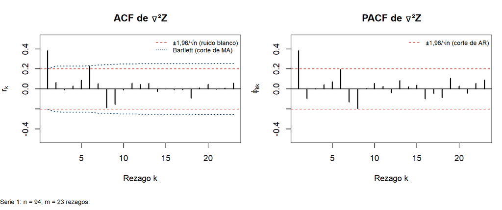

Serie 1: ACF y PACF de ∇²Z, n = 94, m = 23.

Serie 1: tabla EACF de ∇²Z (x: |valor| > 2/√(n−k−q−1)).

| AR MA | 0 | 1 | 2 | 3 | 4 | 5 | 6 | 7 | 8 | 9 | 10 | 11 | 12 | 13 |
| --- | --- | --- | --- | --- | --- | --- | --- | --- | --- | --- | --- | --- | --- | --- |
| 0 | x | o | o | o | o | x | o | o | o | o | o | o | o | o |
| 1 | x | o | o | o | o | x | o | x | o | o | o | o | o | o |
| 2 | o | o | o | o | o | o | o | o | o | o | o | o | o | o |
| 3 | x | o | o | o | o | o | o | o | o | o | o | o | o | o |
| 4 | x | x | o | o | o | o | o | o | o | o | o | o | o | o |
| 5 | x | o | o | x | o | o | o | o | o | o | o | o | o | o |
| 6 | x | x | x | x | x | o | o | o | o | o | o | o | o | o |
| 7 | x | x | o | o | o | x | o | o | o | o | o | o | o | o |

- **ACF.** $r_1$ = 0,383 sale de las dos bandas. Después, todos los $r_k$ quedan dentro de las bandas de Bartlett; $r_6$ = 0,227 toca la banda de ruido blanco (0,202), pero no la de Bartlett. La ACF se corta después del rezago 1, lo que corresponde a un MA(1).
- **PACF.** $\hat\phi_{11}$ = 0,383 sale de la banda y el resto queda dentro ($\hat\phi_{66}$ = 0,196 y $\hat\phi_{88}$ = -0,196 quedan al borde). La PACF también se corta después de 1, lo que corresponde a un AR(1).
- **Por qué no se distinguen.** Con $\rho_1 \approx 0{,}38$, un MA(1) tendría $\phi_{22} = -\rho_1^2/(1-\rho_1^2) \approx -0{,}17$, y un AR(1) tendría $\rho_2 = \phi^2 \approx 0{,}15$. Ambos valores están por debajo de la banda (≈ 0,20 con n = 94), así que la muestra no puede separar las dos formas.
- **EACF.** La fila 0 tiene **o** en MA 1 a 4, con una **x** aislada en MA 5 (el $r_6$ de la ACF). La fila 2 es toda **o** desde MA 0, y el triángulo de **o** más limpio arranca en (1, 1) y (2, 0).

### 5.1.2 Serie 2: W = ∇ln Z

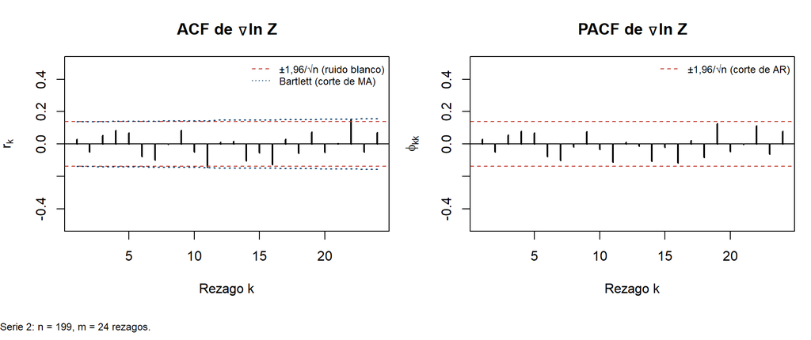

Serie 2: ACF y PACF de ∇ln Z, n = 199, m = 24.

Serie 2: tabla EACF de ∇ln Z (x: |valor| > 2/√(n−k−q−1)).

| AR MA | 0 | 1 | 2 | 3 | 4 | 5 | 6 | 7 | 8 | 9 | 10 | 11 | 12 | 13 |
| --- | --- | --- | --- | --- | --- | --- | --- | --- | --- | --- | --- | --- | --- | --- |
| 0 | o | o | o | o | o | o | o | o | o | o | o | o | o | o |
| 1 | x | o | o | o | o | o | o | o | o | o | o | o | o | o |
| 2 | x | o | o | o | o | o | o | o | o | o | o | o | o | o |
| 3 | x | o | x | o | o | o | o | o | o | o | o | o | o | o |
| 4 | x | o | x | x | o | o | o | o | o | o | o | o | o | o |
| 5 | x | x | x | x | o | o | o | o | o | o | o | o | o | o |
| 6 | x | x | o | o | x | x | o | o | o | o | o | o | o | o |
| 7 | x | x | o | x | x | o | o | o | o | o | o | o | o | o |

- **ACF y PACF.** Ningún valor de los primeros diez rezagos sale de las bandas ($r_1$ = 0,029, $\hat\phi_{11}$ = 0,029). Hay 2 de 24 autocorrelaciones fuera de la banda de ruido blanco (rezagos 11 y 22), apenas al borde. Es lo que se espera por azar: con 24 rezagos y bandas del 95 %, se espera que salga una o dos aunque la serie sea ruido blanco. Además, los rezagos 11 y 22 semanas no tienen ninguna lectura en el contexto.
- **EACF.** La fila 0 es toda **o**, de modo que el vértice está en (0, 0).
- **Lectura.** El rendimiento semanal se comporta como ruido blanco: $\ln Z_t$ es una caminata aleatoria con deriva.

### 5.1.3 Serie 3: W = ∇Z

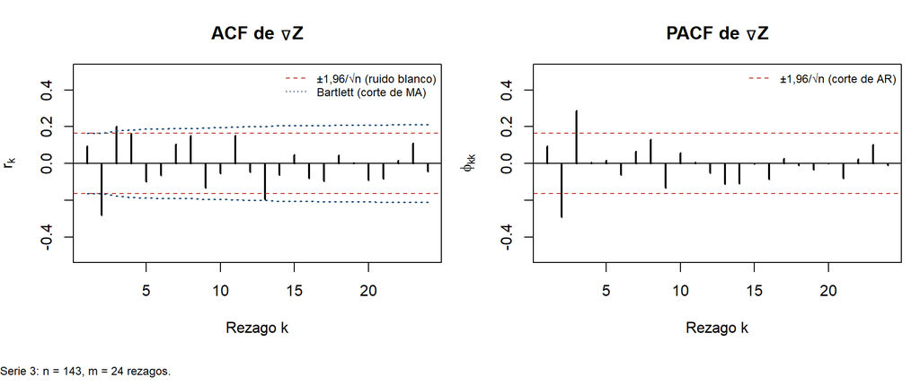

Serie 3: ACF y PACF de ∇Z, n = 143, m = 24.

Serie 3: tabla EACF de ∇Z (x: |valor| > 2/√(n−k−q−1)).

| AR MA | 0 | 1 | 2 | 3 | 4 | 5 | 6 | 7 | 8 | 9 | 10 | 11 | 12 | 13 |
| --- | --- | --- | --- | --- | --- | --- | --- | --- | --- | --- | --- | --- | --- | --- |
| 0 | o | x | x | o | o | o | o | o | o | o | o | o | x | o |
| 1 | x | o | x | x | o | o | o | o | x | o | o | o | o | o |
| 2 | x | x | x | o | o | o | o | o | o | o | o | o | o | o |
| 3 | o | o | x | o | o | o | o | o | o | o | o | o | o | o |
| 4 | x | o | o | o | o | o | o | o | o | o | o | o | o | o |
| 5 | x | o | o | o | x | o | o | o | o | o | o | o | o | o |
| 6 | x | o | o | o | x | o | o | o | o | o | o | o | o | o |
| 7 | x | x | x | o | x | o | o | o | o | o | o | o | o | o |

- **ACF.** $r_1$ = 0,093 queda dentro. $r_2$ = -0,281 y $r_3$ = 0,200 salen de las bandas de Bartlett (0,165 y 0,178). $r_4$ = 0,163 toca la banda de ruido blanco pero queda dentro de la de Bartlett (0,184), y de ahí en adelante todo queda dentro, salvo $r_{13}$ al borde. La ACF se corta después del rezago 3, lo que corresponde a un MA(3).
- **PACF.** $\hat\phi_{22}$ = -0,292 y $\hat\phi_{33}$ = 0,288 salen de la banda, y $\hat\phi_{44}$ = 0,005 ya es prácticamente cero. La PACF se corta después de 3, lo que corresponde a un AR(3).
- **EACF.** La fila 0 tiene **x** en MA 1 y 2, y desde MA 3 es **o** (con una **x** aislada en MA 12). El vértice más claro está en (0, 3). La fila 3 tiene **o** en MA 0 y 1, pero una **x** en MA 2, así que el triángulo del AR(3) no está limpio. Los triángulos que arrancan en (4, 1) y (2, 3) son menos parsimoniosos.

## 5.2 Modelos candidatos

Las formas teóricas que se usan son las siguientes:

- **AR(p):** la ACF decae (exponencial o sinusoidal) y la PACF se corta después de $p$; en la EACF, el vértice está en (p, 0).
- **MA(q):** la ACF se corta después de $q$ y la PACF decae; el vértice está en (0, q).
- **ARMA(p, q):** las dos decaen a partir de $q - p$ y $p - q$; el vértice está en (p, q).

Con muestras de este tamaño, “decae” y “se corta” se confunden cuando los valores siguientes son menores que las bandas. Por eso se lleva más de un candidato y el AIC, el SBC y la validación de las secciones 6 y 7 deciden.

Modelos candidatos de cada serie para la sección 6 (en la notación ARIMA(p, d, q) de g(Z_t)).

| Serie | Candidato | Papel | Evidencia |
| --- | --- | --- | --- |
| 1 | ARIMA(0,2,1) sin constante | principal | ACF se corta tras 1 (Bartlett); EACF fila 0 con o desde MA 1 |
| 1 | ARIMA(1,2,0) sin constante | principal | PACF se corta tras 1; EACF fila 2 limpia desde MA 0 |
| 1 | ARIMA(1,2,1) sin constante | contraste | vértice (1, 1) de la EACF; mixto más simple |
| 2 | ARIMA(0,1,0) con constante | principal | ACF y PACF sin valores fuera de banda; vértice (0, 0) |
| 2 | ARIMA(1,1,0) con constante | contraste | por si r₁ = 0,03 esconde dependencia; también sirve de sobreajuste |
| 2 | ARIMA(0,1,1) con constante | contraste | ídem, por el lado MA |
| 3 | ARIMA(0,1,3) con constante | principal | ACF se corta tras 3 (Bartlett); vértice (0, 3) de la EACF |
| 3 | ARIMA(3,1,0) con constante | principal | PACF se corta tras 3 |

**Serie 1.** Se llevan **ARIMA(0,2,1)** y **ARIMA(1,2,0)**, sin constante. Las dos formas son compatibles con lo observado: un único valor importante en la ACF y en la PACF, y nada más fuera de las bandas que corresponden. Se agrega **ARIMA(1,2,1)** porque la EACF marca (1, 1). Se descartan:

- **Órdenes de 2 o más:** $r_2$ y $\hat\phi_{22}$ son pequeños.
- **Términos en el rezago 6:** $r_6$ y $\hat\phi_{66}$ están solos y al borde, sin ninguna lectura física. No hay estacionalidad y seis trimestres no son un ciclo del plan de minado.
- **Constante:** la sección 4.4 no la respalda.

**Serie 2.** El candidato principal es **ARIMA(0,1,0) con constante**, la caminata aleatoria con deriva para $\ln Z_t$, que reúne las tres piezas: ACF, PACF y vértice (0, 0). Como la sección pide más de un candidato, se llevan también **ARIMA(1,1,0)** y **ARIMA(0,1,1)** con constante. Sirven para verificar que el término adicional no es significativo y anticipan el sobreajuste de la sección 7. Los valores al borde en los rezagos 11 y 22 no justifican un término en esos rezagos, por la razón dicha arriba.

**Serie 3.** Se llevan **ARIMA(0,1,3)** (ACF que se corta tras 3, con vértice (0, 3) en la EACF) y **ARIMA(3,1,0)** (PACF que se corta tras 3), ambos con constante. La EACF favorece el MA(3), porque el triángulo del AR(3) tiene una **x** en (3, 2). En el MA(3) se espera $\hat\theta_1$ pequeño, porque $r_1$ lo es; aun así se estima completo, porque el curso no usa modelos con coeficientes restringidos a cero. Se descartan:

- **Órdenes de 1 o 2:** dejarían fuera $r_3$ y $\hat\phi_{33}$, que son claramente distintos de cero.
- **Mixtos (2, 3) y (4, 1):** tienen cinco coeficientes, frente a tres de los principales, y ninguna pieza los pide antes que a los candidatos simples.

# 6 Estimación y selección

# 7 Validación del modelo